# Simplex Take-Home: Non-ergodic Mess3 Transformer Study

**Candidate:** Matthew Fong  
**Date:** 2026-04-15

## Task 1 — Experimental Setup

### Generative Process

I train a small transformer via next-token prediction on a **non-ergodic** dataset built from K=3 Mess3 hidden Markov models. Each sequence in the training corpus is generated by exactly one randomly-chosen source; the joint process over sequences has no single stationary distribution.

The three Mess3 sources are parameterised by (*α*, *x*) where *α* controls diagonal dominance (autocorrelation) and *x* controls cross-emission probability:

| Source | *α* | *x* | Character |
| --- | --- | --- | --- |
| 0 | 0.95 | 0.05 | Highly structured — stays in state, tokens very predictable |
| 1 | 0.60 | 0.15 | Moderate structure |
| 2 | 0.30 | 0.25 | Noisy — rapid state mixing, tokens near-uniform |

Vocabulary ${0, 1, 2, BOS = 3}$, vocab size 4. BOS is prepended to every sequence; the model never predicts BOS.

### Model and Training

A two-layer causal transformer (TransformerLens `HookedTransformer`), *d*<sub>model</sub> = 128, 4 heads, *d*<sub>mlp</sub> = 512, context length 17 (~440k parameters). Trained with AdamW (lr=1e-3, weight_decay=1e-4), linear warmup then cosine decay, 10k steps at batch size 256.

### Why is this structure interesting for language models?

Real language is not ergodic. A sequence from a scientific journal and a sequence from a social media post have different transition probabilities — different generative processes — and the model must track which one is active rather than averaging over all of them. The ensemble average is not the time average.

The non-ergodic Mess3 setup is a minimal, fully controlled analogue of this domain and register structure: multiple distinct sources, each internally consistent, never mixed within a sequence. It is a clean test of whether transformers can perform **hierarchical Bayesian inference** — inferring not just “what hidden state is the generator in” but “which generator is active.” In natural language we cannot compute the ground-truth posterior over sources, but in this synthetic setting we can. This lets us ask precisely: does the model’s residual stream track the correct Bayesian posterior, and does it do so in the orthogonal factored geometry the paper predicts?

If the factored world hypothesis extends to real LLMs — which the paper’s inductive bias argument suggests it should — then the factors the model discovers may correspond to interpretable, separable aspects of language: topic, syntactic register, factual domain, or whether a claim is hedged or confident. If those factors live in orthogonal subspaces of the residual stream, they become readable and adjustable independently. The non-ergodic Mess3 experiment is the controlled proof-of-concept that makes that larger goal tractable to reason about formally.

### Other experiments with more time

The most direct extension would be applying CEV analysis to a large pretrained LLM’s residual stream with no architectural modifications. Feed the model a large corpus of diverse text passages drawn from distinct domains (legal, scientific, literary, conversational), collect residual stream activations at each token position, and run PCA. Is effective dimensionality consistent with factored structure? Do passages from different domains cluster into distinct geometric regions? A complementary experiment would adapt the vary-one procedure to natural language using minimal pairs — text pairs differing in exactly one property (e.g. grammatical number, tense, topic) — to isolate candidate factor subspaces and test their pairwise orthogonality using the overlap metric from the paper.

## Task 2 — Pre-Registered Geometric Prediction

*All predictions written before any training run or residual stream analysis.*

### 2.1 What Makes This Setup Different From the Paper

The paper’s main experiments study processes that are independent or conditionally independent, where multiple factors run in parallel and the model tracks belief over all of them simultaneously. This setup introduces a qualitatively different structure: **non-ergodicity**. Each training sequence is generated by exactly one of three Mess3 sources, fixed for its entire length, and the joint process over sequences has no single stationary distribution — the ensemble average is not the time average.

This means the model must perform **hierarchical inference**: simultaneously inferring which source is active and tracking the internal hidden state of that source. These are two nested levels of uncertainty that the paper’s framework did not directly study.

### 2.2 Structure of the Optimal Belief State

The sufficient statistic for optimal next-token prediction is the joint belief vector:

**b**<sub>*t*</sub> = {*w*<sub>*k*</sub>(*t*), **h**<sub>*k*</sub>(*t*)}<sub>*k* = 0</sub><sup>*K* − 1</sup>

where *w*<sub>*k*</sub>(*t*) = *P*(source = *k* ∣ *x*<sub>1 : *t*</sub>) and **h**<sub>*k*</sub>(*t*) = *P*(hidden state ∣ *x*<sub>1 : *t*</sub>, source = *k*) ∈ *Δ*<sup>2</sup>.

The source weights live in a 2-simplex *Δ*<sup>2</sup>. Each per-source hidden belief also lives in a 2-simplex *Δ*<sup>2</sup> (3 Mess3 hidden states). Together, the full belief covers 3*K* = 9 combinations constrained to sum to 1:

**b**<sub>*t*</sub> ∈ *Δ*<sup>8</sup> ⊂ ℝ<sup>9</sup>, dim = 3*K* − 1 = 8

breaking down as *K* − 1 = 2 free source weights plus 2*K* = 6 free hidden state coordinates.

An important contrast with the paper: their *K* parallel independent factors yield a factored representation exponentially cheaper than the joint one. Here, *K* non-ergodic sources have the *same* total dimensionality as the joint representation — 8 dimensions either way. The question is therefore not about dimensional savings but entirely about **geometric structure and organization**.

### 2.3 Geometric Predictions

#### Geometry at long context

At late context positions, the residual stream should organize into *K* = 3 separated clusters in PCA space, one per source. Within each cluster, activations should lie on a 2-dimensional manifold — a distorted image of the Mess3 belief simplex *Δ*<sup>2</sup> for that source, consistent with Figure 2a of the paper.

If the transformer internalizes the factored structure, this cluster structure is the visible consequence of a deeper organization: the residual stream partitions into 4 approximately orthogonal subspaces according to the Factored World Hypothesis:

- **1 source subspace** (2D): encodes *w*<sub>*k*</sub>(*t*). The three clusters in PCA space are the three corners of this subspace’s *Δ*<sup>2</sup>.
- **3 hidden subspaces** (2D each): one per source, each encoding **h**<sub>*k*</sub>(*t*) as a copy of that source’s Mess3 belief simplex.

Total predicted dimensions: $2 + 3 × 2 = 8$. Pairwise subspace overlap should be near zero — an overlap matrix with diagonal $≈ 1$, off-diagonal $≈ 0$.

Source 0 (*α* = 0.95) is most statistically distinctive, so its cluster should be most cleanly separated. Sources 1 and 2 should be closer, particularly at short context.

#### How geometry changes with context position

At *t* = 0 (BOS only), the model has no source evidence; the full 8-dimensional joint belief is relevant. As *w*<sub>*k*</sub>(*t*) concentrates onto one source, the predictive state collapses toward a single 2D simplex. Predicted effective dimensionality:

eff-rank(*t* = 0) ≈ 8, eff-rank(*t* → ∞) ≈ 2

This gives a novel testable prediction: **effective dimensionality is a monotonically decreasing function of context position**, with rate of decrease tracking source entropy *H*[*k* ∣ *x*<sub>1 : *t*</sub>]. Disambiguation rate is governed by KL divergence between sources’ next-token distributions, so Source 0 should be identified fastest.

#### How geometry changes across layers

Following the paper’s general finding, geometric structure should be most pronounced at final layers: high effective dimensionality after the embedding, emerging cluster separation after layer 1, and cleanest factored geometry after layer 2.

### 2.4 Alternative Geometries

**Joint representation.** Single 8D simplex over all (source, hidden state) combinations, no sub-clustering, no orthogonal organization.

**Source-only representation.** Three separated clusters but no Mess3 simplex geometry within each — the model tracks source identity but not within-source hidden state. Plausible given the absence of compression pressure.

**Collapsed ergodic representation.** A single cloud with blended Mess3 geometry and no source clustering — the model fails to discover the non-ergodic structure entirely.

The full factored structure (FWH) is the pre-registered prediction based on the inductive bias argument in the paper. Source-only is considered the most plausible alternative.

### 2.5 Geometric Intuition

The full belief space is a product of simplices: one source-weight triangle and three hidden-belief triangles. The FWH predicts the transformer embeds each in a separate, roughly orthogonal 2D subspace of ℝ<sup>128</sup> — four orthogonal triangles, each independently tracking one level of the hierarchy.

Geometrically, the evolution with context is a progressive collapse: the source weight triangle sharpens toward a corner as evidence accumulates, the losing sources’ hidden triangles become irrelevant, and the full 8D structure contracts to an effectively 2D structure at sequence end.

## Task 3 — Residual Stream Geometry Analysis

### 3.1 Global Structure at Final Context Position

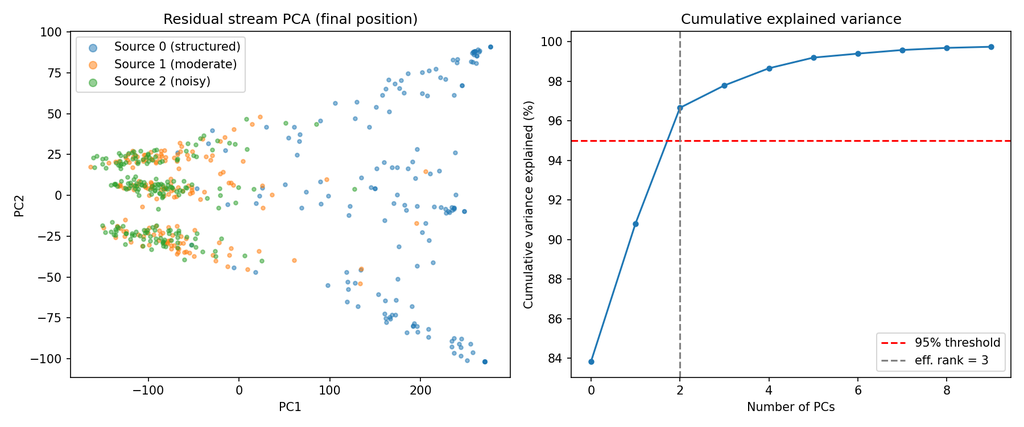

Residual stream PCA at final token position

After training to a final cross-entropy loss of 0.9438 nats (theoretical optimum ~0.89 nats), PCA of residual stream activations at the final token position reveals that the first 3 principal components explain 96.7% of total variance — effective rank 3, substantially lower than the predicted 8 dimensions for either the joint or factored representation. The model has found a more compressed solution than either hypothesis anticipated.

The dominant structure is a clean separation of Source 0 (*α* = 0.95) from Sources 1 and 2 along PC1, which alone accounts for 83.8% of variance. Sources 1 and 2 overlap heavily. This asymmetry is expected: Source 0 has dramatically lower token entropy than Sources 1 and 2 (which differ by only ~0.05 nats in entropy rate), making it far more statistically distinctive within a 16-token context window.

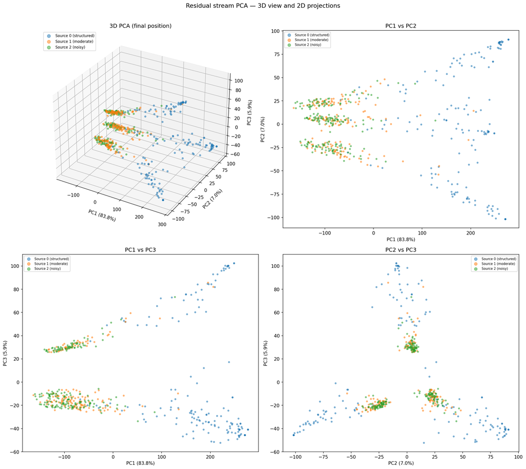

3D PCA and 2D projections

PC1 functions as a source-identity axis separating Source 0 from the rest. PC2 and PC3 capture within-cluster variation: Source 0’s cluster is visibly elongated along these axes, consistent with Mess3 belief simplex geometry. The overall geometry is better described as one dominant source-identity axis plus lower-dimensional within-cluster variation, rather than the four orthogonal subspaces predicted by the FWH.

### 3.2 How Geometry Evolves With Context Position

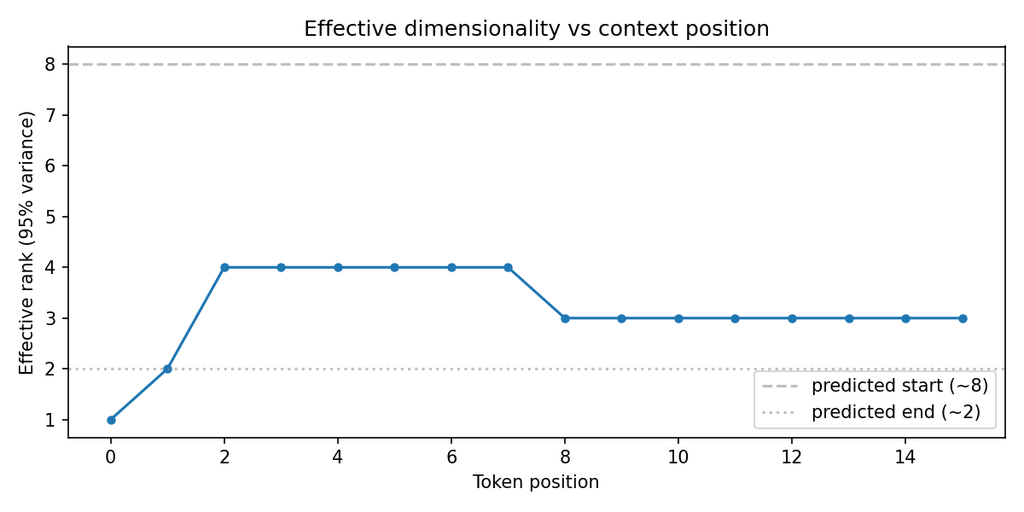

Effective rank by token position

Tracking effective rank across token positions reveals a non-monotonic trajectory not anticipated in the pre-registered predictions:

- **Position 0 (BOS):** Rank = 1. All sequences are identical at BOS — no variance.
- **Positions 1–7:** Rank rises to 4 as the model accumulates evidence about source identity and hidden state simultaneously. This is the source-disambiguation phase.
- **Positions 8–15:** Rank drops to 3 and stabilizes. Source identity has been sufficiently resolved, and the representation collapses onto the identified source’s belief simplex.

The trajectory 1 → 4 → 3 tells a coherent story: the model expands its representational dimensionality to perform source inference, then contracts once inference has converged. The final rank of 3 (rather than 2) likely reflects residual uncertainty between Sources 1 and 2, which remain difficult to disambiguate within 16 tokens.

### 3.3 Linear Decodability of Belief Components

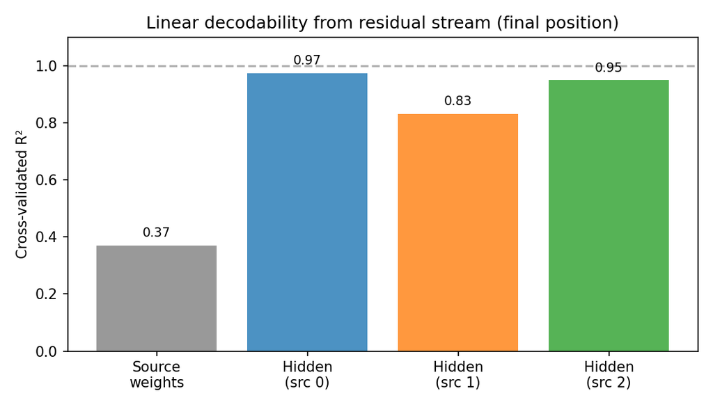

Linear decodability at final position

Linear regression from residual stream activations to ground-truth belief states reveals a striking asymmetry between the two levels of the hierarchy:

**Hidden state beliefs are almost perfectly linearly decodable.** Cross-validated *R*<sup>2</sup> values at the final position are 0.97 (Source 0), 0.83 (Source 1), and 0.95 (Source 2) — despite the model never receiving explicit hidden-state supervision. The within-source Mess3 belief geometry is linearly accessible from the residual stream, consistent with the FWH prediction.

**Source weight beliefs are poorly linearly decodable** (*R*<sup>2</sup> = 0.37). This is not because the information is absent — PCA shows clear cluster separation for Source 0 — but because source identity appears to be encoded as categorical cluster membership rather than as a continuous linear direction. A nonlinear classifier would likely achieve high accuracy.

This asymmetry has a natural explanation grounded in the training objective. The hidden state directly determines the next-token distribution, so the model has strong gradient pressure to encode it linearly and precisely. Source identity is a higher-level latent variable that influences predictions only indirectly, through its effect on which hidden state dynamics are operating. The model uses source identity for clustering but has no gradient pressure to maintain it as a continuous linear quantity.

### 3.4 Comparison to Pre-Registered Predictions

[output not shown]

The most significant departure is in the effective rank trajectory. The 8 → 2 monotonic decrease assumed the model would represent full source uncertainty at sequence start. Instead the model found a more compressed strategy: 4 dimensions during active disambiguation, collapsing to 3 once the dominant source is identified, never requiring the full 8D joint belief space. This likely reflects the inductive bias toward dimensionally efficient representations documented in the paper — the model found a solution cheaper than the full joint representation even though no compression savings were theoretically guaranteed in this setting.

The hidden belief decodability results are the clearest success of the theoretical framework. Even in a non-ergodic setting where the dimensional savings argument does not apply, the model precisely tracks within-source Mess3 belief geometries in linearly accessible subspaces — consistent with the paper’s core claim that next-token prediction induces geometrically organized belief representations. However, the failure to linearly encode source identity suggests the inductive bias toward factored linear representations is weaker for higher-level latent variables that influence predictions only indirectly.

## Task 4 — Geometry Under Varying Source Distinguishability

### 4.1 Motivation

Task 3 revealed two related findings that invite systematic follow-up. First, source identity was poorly linearly decodable (R² = 0.37) despite clear cluster separation in PCA space, suggesting categorical rather than continuous encoding. Second, Sources 1 and 2 failed to separate cleanly, likely because their entropy rates are too similar to disambiguate within 16 tokens. Both findings point to the same underlying variable: **source distinguishability**.

This experiment varies distinguishability directly by fixing two anchor sources at the extremes and sweeping a third through the parameter space between them. The goal is to identify when FWH predictions succeed or fail, and whether the encoding of source identity transitions from categorical to linear as sources become more distinct.

### 4.2 Experimental Design

Two sources are fixed as anchors:

| Source | *α* | *x* | Role |
| --- | --- | --- | --- |
| Anchor A | 0.95 | 0.05 | Highly structured, low entropy |
| Anchor B | 0.30 | 0.25 | Noisy, high entropy |

A probe source sweeps between them via a mixing parameter *λ* ∈ [0, 1]:

*α*(*λ*) = 0.95 − 0.65*λ*, *x*(*λ*) = 0.05 + 0.20*λ*

At *λ* = 0 the probe matches Anchor A; at *λ* = 1 it matches Anchor B. Suggested sweep: *λ* ∈ {0, 0.1, 0.2, 0.3, 0.5, 0.7, 1.0}, with a separate transformer trained from scratch for each condition. Sweeping *λ* continuously tunes the KL divergence between the probe and both anchors — which theory predicts is the primary driver of disambiguation speed and representational geometry.

### 4.3 What We Would Measure

For each *λ*, the same analysis pipeline as Tasks 2–3:

**Geometry:** PCA cluster separation at final position; effective rank at final position and across token positions; pairwise subspace overlap.

**Linear decodability:** Cross-validated *R*<sup>2</sup> for source weights and hidden beliefs for all three sources.

**Nonlinear vs. linear decodability of source identity:** Train a k-nearest-neighbor classifier (k=5) and a linear classifier on final-position residual stream activations. The gap between KNN and linear accuracy is the key diagnostic — a large gap confirms categorical encoding; convergence of the two suggests the model has shifted to a linear encoding of source identity consistent with the FWH.

### 4.4 What This Would Tell Us

**When does the FWH succeed?** Source identity is only worth encoding as a separate factor if sources are statistically distinguishable. This experiment maps out the distinguishability threshold below which the FWH prediction breaks down — directly connecting the theory’s requirements to an empirically measurable parameter.

**How does source encoding transition from categorical to linear?** The Task 3 finding may be a consequence of insufficient distinguishability rather than a fundamental property of non-ergodic structure. If at high *λ* the linear-nonlinear gap closes, it would suggest transformers encode source identity linearly when evidence is sufficient and fall back to categorical encoding when it is not — a new finding about how transformers handle uncertain hierarchical inference that goes beyond what the paper studied.